# U.S. STATE CONSTITUTIONS WORD COUNT: Revisiting Clouse’s Dataset. Trabalho Final - MQCP

Amanda Lopes; Ana Vaz; Bárbara Maia; Isabel Eirado

Dezembro/2020

> *laws and institutions must go hand in hand with the progress of the human mind. As that becomes more developed, more enlightened, as new discoveries are made, new truths disclosed, and manners and opinions change with the circumstances, institutions must advance also, and keep pace with the times.” - Thomas Jefferson, 1816*<

# Resumo

O objetivo deste trabalho é revistar o Banco de Dados **“US State Constitutions Dataset”**, criado por Julia Gervaise-Rubicam Clouse (CLOUSE, 2019), e propor um novo olhar e análises aos dados ali apresentados. O dataset converte textos constitucionais (historicos e atuais) dos estados dos EUA para dados quantificáveis utilizando-se da categorização destes textos. A ideia do trabalho de Clouse (2019) é analisar a evolução das ideias e prioridades políticas nos 50 estados do país, e analisar a mudança constitucional dos estados ao longo do tempo. Utilizando-se dessa base de dados, este trabalho propõe-se a analisar as mudanças constitucionais a partir do número de palavras totais das constituições e das regras formais que abarcam os três Poderes - Executivo, Legislativo e Judiciário. Conclui-se que há um campo fértil para comparação entre as constituições estaduais e se observam tendências gerais nos tópicos de foco dos estados. O teste de hipótese realizado demonstra que as constituições atuais são maiores e mais abrangentes que as constituições históricas, e foi possível fazer algumas relações entre as variáveis. Pontua-se, por fim, que este tipo de análise se beneficiaria de uma análise qualitativa em profundidade, a fim de melhor avaliar as categorias analíticas e tirar conclusões combinadas entre dados qualitativos e quantitativos.

# Introdução

- Objeto: Mudança constitucional no federalismo norte-americano
- Objetivo principal: Analisar a evolução de ideias e prioridades políticas nos 50 estados estadunidenses a partir das mudanças constitucionais
- Objetivos específicos:
1. Observar mudanças constitucionais a partir das variações das palavras totais das constituições vigentes
2. Verificar a variação entre o número de constituições implementadas ao longo do tempo
3. Observar, a partir de um índice, a mudança proporcional entre os três poderes nas constituições estaduais
4. Demonstrar padrões de mudança constituicional ao longo do tempo
- Contextualização (justificativa)

A organização do federalismo estadunidense dá às unidades subnacionais considerado potencial para inovações constitucionais e experimentação política (“espaço constitucional”), inclusive em comparação à maior parte de outras federações (BURGESS, TARR e MARKO, 2004).Essa possibilidade de mudança foi utilizada pelos estados de maneira frequente - seja pela substituição completa, seja pelo emendamento das Cartas vigentes. Diferentemente do que ocorre com a Constituição Federal, emendas e mudanças nas Constituições Estaduais são relativamente fáceis, além de congregarem uma gama de atores, tendo um caráter popular mais visível, dado que são propostas ou votadas pela população (ACIR, 1989).

Além disto, Woodward-Burns (2007) irá apontar que é justamente a revisão constitucional estadual que resolve as controvérsias constitucionais nacionais, evitando emendas nas constitucional federais e atuando na resulução de conflitos, em escala nacional, entre os poderes. De fato, enquanto em nível federal, somente uma Constituição foi ratificada, com 27 emendas, os estados Americanos tem uma larga produção constitucional, com 153 constituições adotadas<sup>1</sup> ^1[Aqui, utilizamos a contagem feita por Clouse (2019). É importante apontar que sua contagem, conforme será explicitados nas notas metodológicas, diverge da contagem de outros autores, como o Book of States (2012), que aponta para a exitência de 145], sendo que o número de emendas, até 2013, chegava a quase 10.000 (TARR, 2016).

O que está por trás da frequência das alterações, e é particularmente o objeto de interesse aqui, são os tipos de mudanças propostos pelas novas constituições. As constituições estaduais tendem a ser mais longas que a Constituição Federal por serem mais detalhadas no que tange as relações cotidianas entre o governo e a população dos estados (ACIR, 1989). Além disso, boa parte das constituições estaduais irá abordar tópicos não abordados na CF, como Governo Local e Educação (TARR, 2016). Mas, em grande medida, representam escolhas políticas dos próprios estados, as necessidades ali encontradas e filosofias de governo próprias (ACIR, 1989).

Assim, se por um lado se entende que as Constituições estaduais completam e balanceiam a Constituição Federal, e, portanto, são essenciais para o funcionamento do sistema federativo estadunidense, por outro a frequência das mudanças das constituições representa um lugar fértil para entender: a) de que forma as ideias e prioridades políticas vêm evoluindo nos 50 estados; b) de que forma os estados vêm se adaptando às necessidades de novas ações políticas, sociais, domésticas e externas.

De modo, geral, portanto, observa-se que a importância da compreensão das constituições subnacionais está justamente no fato de que a maior parte das revisões constitucionais nos EUA acontecem em nível estadual. Para além deste fato, reforça-se que a compreensão das instituicições estadunidenses e do sistema federalista do país se apoiam, largamente, também neste nível.

- Pergunta: É possível observar padrões de mudança nas constituições estaduais dos 50 estados americanos ao longo do tempo?

## Preparando a análise

```r
library(ggplot2)
library(tidyr)
library(dplyr)
library(rmarkdown)
library (infer)
library(tidyverse)
library(tibble)
library(ggpubr)
library(devtools)
devtools::install_github("cardiomoon/webr")
library(webr)
library(forcats)
```

```r
state_const <- read_excel("US-State_Constitutions_Dataset_1776-2017.xlsx")
States_and_Abbreviations <- read_excel("States and Abbreviations.xlsx")
```

# Método

- Utilizamos a base de dados construída por Julia Clouse, conforme informações e fontes dispostas na planilha apresentada abaixo:

```r
state_cons_sources <- read_excel("state_constitutions_sources.xlsx")

state_cons_sources
```

```
## # A tibble: 204 x 4
##    `U.S. State` `Contitution Yea~ Source             `Original Link`
##    <chr>                    <dbl> <chr>              <chr>
##  1 Alabama                   1819 Poore, B.P. (Part~ https://play.google.com/bo~
##  2 Alabama                   1861 Alabama, Legislat~ http://www.legislature.sta~
##  3 Alabama                   1865 Poore, B.P. (Part~ https://play.google.com/bo~
##  4 Alabama                   1867 Poore, B.P. (Part~ https://play.google.com/bo~
##  5 Alabama                   1875 Poore, B.P. (Part~ https://play.google.com/bo~
##  6 Alabama                   1901 Alabama, Contribu~ https://play.google.com/bo~
##  7 Alabama                   2016 Alabama, Legislat~ http://alisondb.legislatur~
##  8 Alaska                    1956 Fairbanks Daily N~ https://newspaperarchive.c~
##  9 Alaska                    2004 Alaska             https://ltgov.alaska.gov/i~
## 10 Arizona                   1912 Arizona, Compiled~ https://play.google.com/bo~
## # ... with 194 more rows
```

- Dadas as fontes utilizadas para elaboração da base de dados, utilizamos a função glimpse para conhecer melhor os dados com os quais estamos lidando.

```r
glimpse(state_const)
```

```
## Rows: 203
## Columns: 38
## $ state                        <chr> "Connecticut", "Delaware", "Maryland",...
## $ constitution_year            <dbl> 1776, 1776, 1776, 1776, 1776, 1776, 17...
## $ statehood                    <dbl> 1788, 1787, 1788, 1788, 1787, 1789, 17...
## $ state_number                 <dbl> 5, 1, 7, 9, 3, 12, 2, 13, 8, 10, 4, 11...
## $ current_constitution         <dbl> 0, 0, 0, 0, 0, 0, 0, 0, 0, 0, 0, 0, 0,...
## $ total_words                  <dbl> 4706, 4233, 8839, 930, 2455, 3886, 604...
## $ preamble                     <dbl> 410, 27, 132, 335, 252, 244, 474, 568,...
## $ state_boundaries             <dbl> 174, 0, 0, 0, 0, 291, 0, 510, 0, 71, 0...
## $ declaration_rights           <dbl> 401, 583, 812, 0, 115, 651, 898, 140, ...
## $ religion                     <dbl> 89, 265, 743, 0, 221, 248, 298, 312, 2...
## $ discrimination               <dbl> 15, 48, 13, 0, 0, 75, 53, 255, 0, 25, ...
## $ private_property             <dbl> 68, 22, 0, 0, 0, 28, 56, 70, 0, 26, 67...
## $ suffrage_elections           <dbl> 72, 231, 842, 68, 71, 282, 244, 79, 0,...
```

[output cut: 25 more lines]

- Trabalhamos, portanto, com uma variável categórica, o nome dos estados, variável categórica, e o restante de variáveis numéricas, que indicam desde o ano em que a constituição foi promulgada (constitution_year) até o número de palavras dedicadas a determinado elemento em cada constituição (exemplo: número de palavras referentes a declaração de direitos em determinada constituição - declaration_rights). Neste trabalho focaremos nas variáveis:
1. statehood - informa o ano em que o estado passou a integrar a Federação dos Estados Unidos da América
2. current_constitution - informa a constituição vigente (1) e as constituições ultrapassadas
3. total_words - informa quantas palavras cada constituição tem, desde a primeira até a vigente
4. legislative - texto que descreve as funções, procedimentos, poderes e limitações da legislatura
5. executive - do texto que descreve as funções, estrutura, poderes e limitações do Poder Executivo
6. judicial - texto que descreve as funções e poderes dos sistemas de tribunais estaduais e dos funcionários do Poder Judiciário

A literatura demonstra que, ao longo do tempo, as Constituições tem se alargado. De acordo com Tarr (2006), a história das Constituições Estaduais dos EUA consiste na mudança constitucional. A expansão e evolução das Constituição já foi alvo de muito interesse por pesquisadores (DEALEY, 2009; BRYCE, 1995), assim como a expansão em termos de número de palavras, isto é, seu tamanho (LUCE, 2009; DE GRAZIA, 1954; STURM, 1982). A novidade da base trazida por Gervais (2019) é a transformação dos textos constitucionais em variáveis quantitativas comparáveis. Assim, parte-se da premissa que as Constituições Estaduais mudam ao longo tempo, se expandindo (fato medido pela quantidade de palavras). Dado que a expansão vem ocorrendo ao longo do tempo, a ideia é verificar se as atuais constituições se expandiram mais do que a média das constituições históricas. Com base nisso, pretende-se verificar se:

*H0:* A variação do número de palavras permance a mesma ao longo das mudanças constitucionais.

*H1:* Há maior variação no número de palavras das Constituições Estaduais correntes, em relação às Constituições anteriores.

Para isso, foi utilizado o teste-t para comparar o tamanho (em termos de número de palavras) das Constituições Atuais e a média do tamanho das Constituições Históricas. Assim, operacionalizou-se como Constituições Históricas a média do número total de palavras de todas as Constituições de cada Estado, excluída a Constituição atual. Enquanto que as Constituições Atuais foram operacionalizadas a partir do número de palavras das Constituições Estaduais atuais.

# Análise e visualização de dados

- Diante do objetivo de compreender as mudanças constitucionais, esta seção será dividida em 3 partes:
1. Análise das mudanças constitucionais pelo número total de palavras nas constituições
2. Análise das mudanças constitucionais pelo número de constituições promulgadas
3. Análise das mudanças constitucionais a partir do Índice de Mudança Proporcional dos Poderes

## Análise das mudanças constitucionais pelo número total de palavras nas constituições

- Inicialmente manipulamos os dados agregando a lista de abreviações à base de dados

```r
state_const <- state_const %>%  left_join(States_and_Abbreviations, constituicoes_poderes, by = "state") %>% rename(state_abrev=abbreviation) #adicionando a abreviação dos estados para facilitar a manipulação e visualização dos dados
```

- Em seguida, com o objetivo de analisar as constituições atuais a partir do total de palavras e as respectivas mudanças com o acréscimo de palavras, iremos manipular os dados, selecionando e filtrando as informações de interesse a partir da base de dados, e, em seguida, as colunas de interesse usando o pacote dplyr.

```r
state_const_current_total_words <- state_const %>%
add_count(state) %>% #criando coluna que informe o total de constituições de cada estado
select(state, constitution_year, current_constitution, total_words, state_number, state_abrev) %>% #selecionando as variaveis de interesse - nome do estado, ano da constituição, constituição atual e total de palavras
  filter(current_constitution == 1) #filtrando apenas as constituições vigentes
```

- Primeiramente, queremos identificar a variação do número de palavras das constituições vigentes em cada Estado. Optou-se por utilizar o tipo de gráfico de pontos (scatter chart) pelos seguintes motivos:
1. O objetivo é observar a distribuição do número de palavras nas constituições de cada estado;
2. Temos duas variáveis em foco - total_word e state - para evidenciar a distribuição de palavras nas constituições dos Estados.
- Por ser um outlier, o Alabama foi excluído do gráfico para não poluir a visualização.

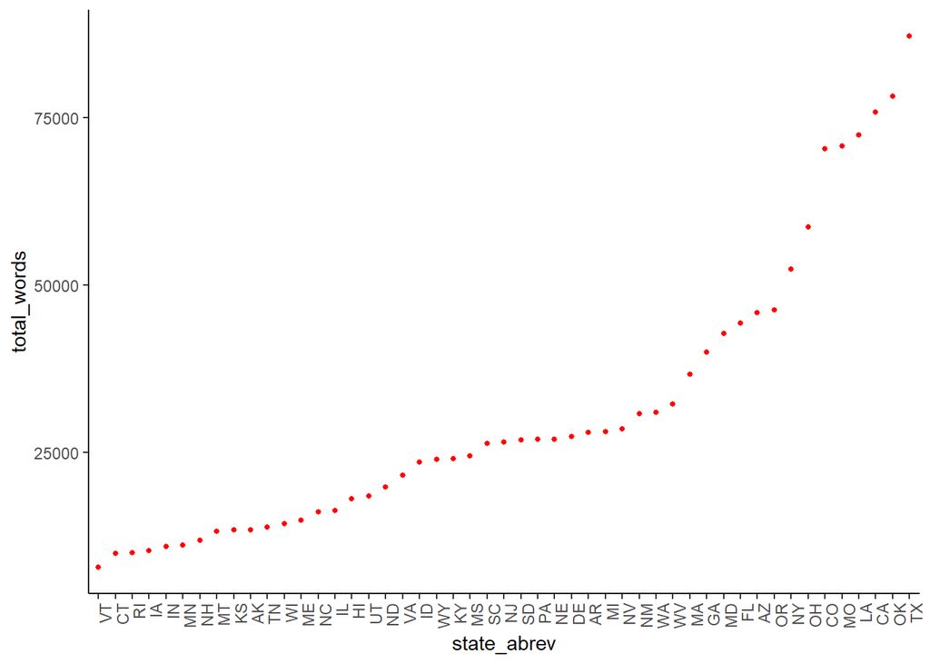

```r
state_const_current_total_words %>% filter(state_abrev != "AL") %>% #excluindo o Alabama
  mutate(state_abrev=fct_reorder(state_abrev, total_words)) %>%
  ggplot(aes(x=state_abrev, y= total_words)) + #definindo os dados a serem projetados nos eixos x e y
  geom_point(color="red", size=1, fill="red") +#definindo a geometria scatter com cor de contorno e preenchimento vermelhas e o tamanho do preenchimento
 theme_classic() +  #definindo o tema classico
  theme(axis.text.x = element_text(angle=90, hjust=1)) #definindo a posição vertical para o eixo x
```

- Após identificar os estados com maior e menor número de palavras na constituição vigente, queremos ver se essa distribuição tem alguma relação com as datas em que foram promulgadas. Assim, para observamos a variação das datas de promulgação das constituições estaduais vigentes, construímos um gráfico de densidade. Optou-se por esse tipo de gráfico por que:
1. O objetivo é observar a distribuição das constituições vigentes por estado ao longo do tempo
2. O ano da constituição vigente (constitution_year) é a variável em foco, variável única
3. Como os Estados Unidos têm muitos estados, totalizando 50, existem muitos “data points” e por isso optou-se pelo histograma em linha, para evidenciar o pico da promulgação de constituições.
- Obs: desta vez o Alabama foi considerado.

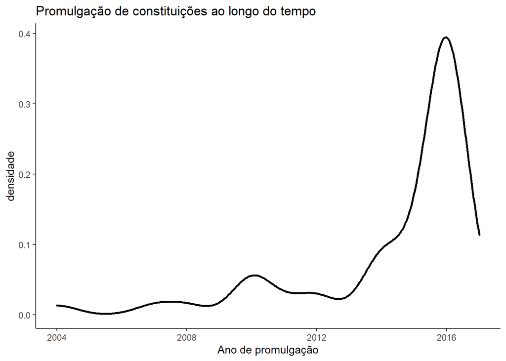

```r
state_const_current_total_words %>% ggplot(aes(x=constitution_year)) + # estabelecendo o eixo x - univa variavel que será ano
  geom_density(color="black", size=1)+ #definindo a cor e o tamanho da linha
  scale_x_continuous() + #definindo os valores a serem expostos no eixo x
  theme_classic() +  #estabelecendo o tema do gráfico para um modelo com fundo branco
  labs(title = "Promulgação de constituições ao longo do tempo",
       x = "Ano de promulgação",
       y = "densidade") #nomeando os eixos
```

## Análise das mudanças constitucionais pelo número de constituições promulgadas

- Após identificar o pico de promulgação das constituições vigentes, segue-se para analisar o número de Constituições promulgadas por cada estado estadunidense, identificando o ano da constituição vigente de cada estado. Sendo assim, essa análise ajuda a verificar a propensão dos estados de implementarem mudanças constitucionais.
- O Alabama não foi excluído dessa análise por não afetar os resultados para o propósito desta subseção.
- Primeiro, manipularemos os dados, criando uma tabela com as informações necessárias para a análise.

```r
#Criando tabela para analisar o total de constituições de cada estado
const_eua_painel <- state_const  %>%
  as_tibble()  %>% #transformando em tibble
  add_count(state) %>% #adicionando uma nova coluna com o número de contagem a partir de um grupo de variaveis
  select(state, n, constitution_year, current_constitution, statehood, state_number, state_abrev) %>% #selecionando as variaveis para trabalhar
  filter(current_constitution == 1) %>% #filtrando as observações que quero manter
  rename(numero_total_constituicoes = 'n') %>% #renomeando a variavel referente ao numero total de constituições
  mutate(regiao = state.region) %>% #criando outra coluna
  mutate(current_constitution = NULL, state_number = NULL) %>% #excluindo colunas
  arrange(desc(numero_total_constituicoes)) #ordenando a tabela
```

- Visualizando os dados.

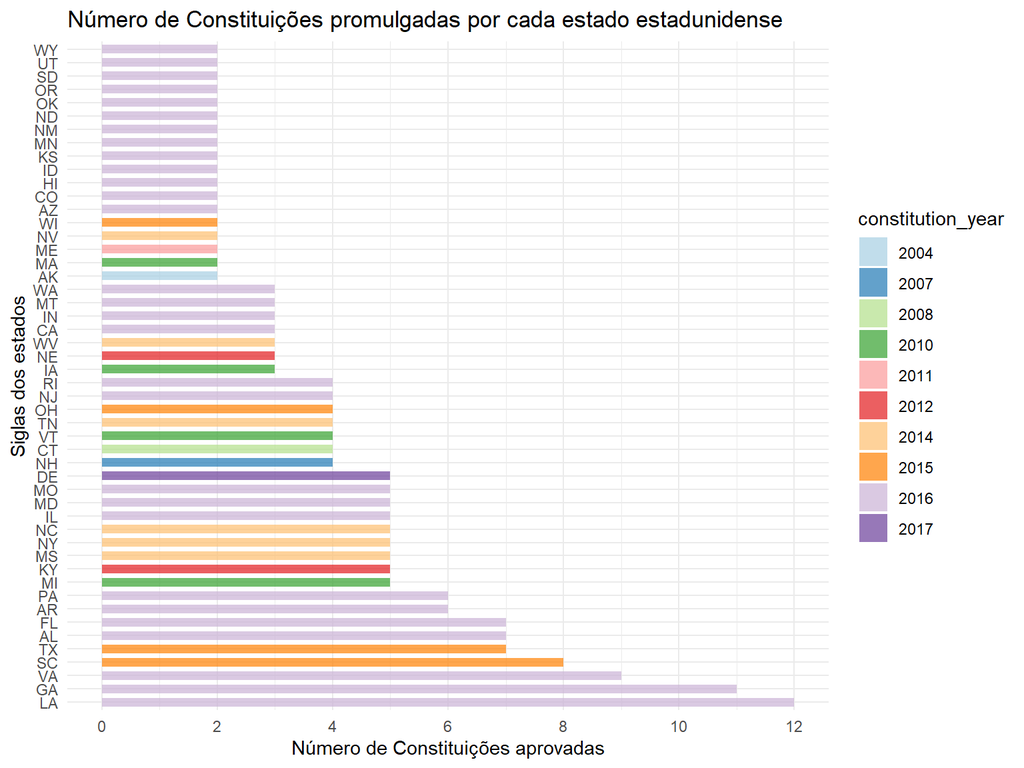

```r
#Criando gráfico com informações sobre o número de Constituições de cada estado
const_eua_painel$constitution_year <- as.factor(const_eua_painel$constitution_year)

const_eua_painel %>%
  select(state_abrev, numero_total_constituicoes, constitution_year) %>%
  ggplot(aes(x = numero_total_constituicoes,
             y = fct_inorder(state_abrev),
             fill = constitution_year)) + #ao definir o mapping no ggplot, as orientações são globais para todos os outros gráficos que virem a seguir
  geom_col(alpha = 0.7, width = .65) +
  scale_x_continuous(breaks = seq(0,12, 2)) +
  scale_fill_brewer(palette = "Paired") +
  ggtitle("Número de Constituições promulgadas por cada estado estadunidense") +
  labs(x = "Número de Constituições aprovadas",
       y = "Siglas dos estados") +
  theme_minimal()
```

```r
const_eua_painel %>% filter(numero_total_constituicoes ==2)
```

```
## # A tibble: 18 x 6
##    state    numero_total_consti~ constitution_ye~ statehood state_abrev regiao
##    <chr>                   <int> <fct>                <dbl> <chr>       <fct>
##  1 Alaska                      2 2004                  1956 AK          South
##  2 Massach~                    2 2010                  1788 MA          West
##  3 Maine                       2 2011                  1820 ME          South
##  4 Nevada                      2 2014                  1864 NV          West
##  5 Wiscons~                    2 2015                  1848 WI          South
##  6 Arizona                     2 2016                  1912 AZ          North C~
##  7 Colorado                    2 2016                  1876 CO          North C~
##  8 Hawaii                      2 2016                  1959 HI          West
##  9 Idaho                       2 2016                  1890 ID          Northea~
## 10 Kansas                      2 2016                  1861 KS          Northea~
## 11 Minneso~                    2 2016                  1858 MN          North C~
## 12 New Mex~                    2 2016                  1912 NM          Northea~
## 13 North D~                    2 2016                  1889 ND          South
## 14 Oklahoma                    2 2016                  1907 OK          North C~
## 15 Oregon                      2 2016                  1859 OR          South
## 16 South D~                    2 2016                  1889 SD          Northea~
## 17 Utah                        2 2016                  1896 UT          South
## 18 Wyoming                     2 2016                  1890 WY          North C~
```

- Diante dos dados sobre o total de constituições que cada estado promulgou, objetivamos identificar se há alguma relação entre a criação do estado e o número de constituições promulgadas, isto é, se a data de criação do estado também influencia em sua propensão à mudança constitucional. Para isso criaremos um gráfico de pontos, pois o objetivo é ver a relação entre duas variáveis.

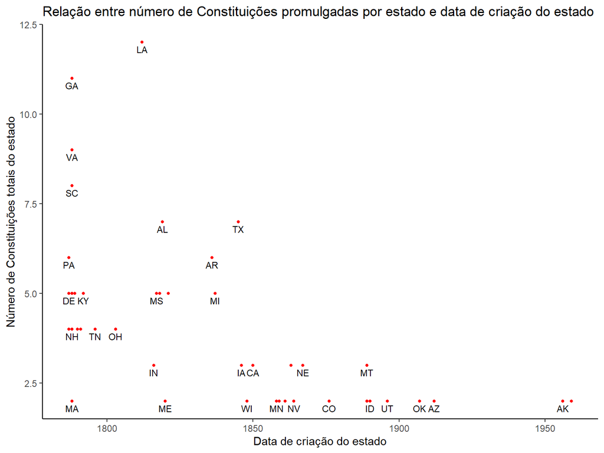

```r
const_eua_painel %>%
  ggplot(aes(x=statehood, y= numero_total_constituicoes)) + #definindo os dados a serem projetados nos eixos x e y e ordenamento a partir do eixo y
  geom_point(color="red", size=1, fill="red") +#definindo a geometria scatter com cor de contorno e preenchimento vermelhas e o tamanho do preenchimento
 geom_text(aes(label=state_abrev), colour = "black", size = 3, vjust = 1.5, position = position_dodge(.9), check_overlap = TRUE)+ #etiquetando o nome do estado para cada ponto no gráfico e usando check_overlap para que nenhuma etiqueta se sobreponha
  ggtitle("Relação entre número de Constituições promulgadas por estado e data de criação do estado") +
  labs(x = "Data de criação do estado",
       y = "Número de Constituições totais do estado") +
  theme_classic()  #definindo o tema classico
```

## Análise das mudanças constitucionais a partir do Índice de Mudança Proporcional dos Poderes

O objetivo desta subseção é fazer uma exploração dos dados a partir de três variáveis: **Lesislative**, **Executive**, e **Judicial**. Para explorar essa relação criamos o Índice de Mudança Proporcional dos Poderes:

$$imp_e = executive/powers$$

$$imp_l = legislative/powers$$

$$imp_j = judicial/powers$$

ONDE:

- IMP = Índice de Mudança Proporcional dos Poderes
- imp_e = Índice de Mudança Proporcional do Poder Executivo
- imp_l = Índice de Mudança Proporcional do Poder Legislativo
- imp_j = Índice de Mudança Proporcional do Poder Judiciário
- executive, legislative e judicial = quantidade de palavras destinada respectivamente às categorias “Executive”, “Legislative” e “Judicial” em cada constituição
- powers = somatório das palavras destinadas aos três poderes - Executivo + Legislativo + Judiciário - em cada constituição

O Objetivo deste índice é fornecer medida de porporção de cada um dos poderes em relação ao total dedicado aos três em cada constituição adotada ou emendada pelos 50 estados. Deste modo, espera-se observar se existe proporcionalidade entre eles, ou seja, se há um equilíbrio, necessário ao mecanismo de Checks and Balances, ou se a presença (aqui entendida como o número de palavras dedicadas a eles) de cada um dos poderes nas constituições foi se alterando ao longo do tempo de forma desigual.

- Para elaborar a análise criamos uma nova tabela e manipulamos os dados

```r
constituicoes_poderes <- state_const %>%
  ##criando um novo data frame com as manipulações
  select(state, constitution_year,current_constitution,
         total_words, legislative, executive, judicial, state_abrev) %>% ##selecionando as variáveis de interesse
   mutate (poderes = (legislative + executive + judicial), ##criando uma nova coluna com os valores somados das categorias executivo, legislativo e judiciário
          imp_l = (legislative/poderes),
##criando o índice de mudança proporcional do legislativo em relação à soma dos poderes
          imp_e = (executive/poderes),
##criando o índice de mudança proporcional do executivo em relação à soma dos poderes
          imp_j = (judicial/poderes))
##criando o índice de mudança proporcional do judiciário em relação à soma dos poderes
```

- A fim de identificarmos a relação entre a quantidade de palavras em cada constituição referente aos poderes e o ano de promulgação das constituições, elaboramos o gráfico a seguir.

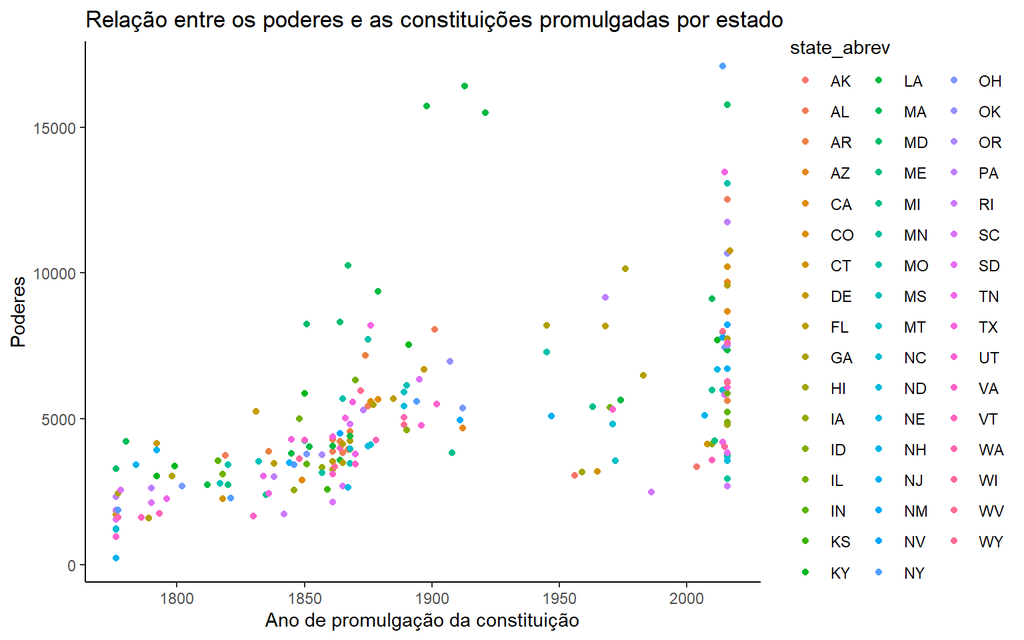

```r
constituicoes_poderes %>%
  ggplot(aes(x = constitution_year,
             y = poderes)) + #determinando os eixos x e y
  geom_point(aes(color = state_abrev)) +
  #determinando a cor por abreviacao/estado
  ggtitle("Relação entre os poderes e as constituições promulgadas por estado") +
  labs(x = "Ano de promulgação da constituição",
       y = "Poderes") +
  theme_classic() #deixando clean
```

- A partir do gráfico é possível identificar que há uma tendência a aumentar o número de regras formais voltadas aos três poderes ao longo do tempo.

- Manipulando os dados e apresentando visualização dos dados a fim de identificar o valor de cada um dos índices de mudança proporcional por estado e ano de promulgação da constituição. Com essa análise, será possível compreender a evolução ao longo do tempo da participação de cada um dos poderes na constituição em termos de palavras.

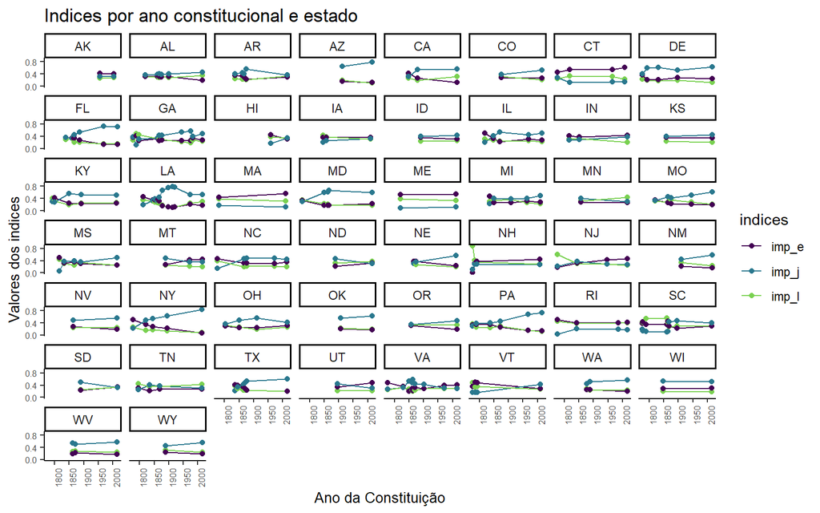

```r
constituicoes_poderes_grafico5 <- constituicoes_poderes %>%
select(constitution_year, state_abrev, imp_l, imp_e, imp_j) %>% #selecionando as variáveis de interesse
  pivot_longer(cols=3:5, names_to = "indices", values_to = "valores")
#pivotando os dados para poder plotar os 3 indices

library(viridis) #baixando o pacote virdis para utilizar paleta de cores
constituicoes_poderes_grafico5 %>%ggplot(aes(x= constitution_year, y= valores, group=indices, color=indices)) +
#determinando eixos x, y e as linhas do grafico para cada um dos indices
  geom_line() + #ordenando as observações a partir do eixo x
  geom_point() +
#inserindo pontos nas linhas do gráfico apra marcar as mudanças
  facet_wrap(~ state_abrev) +
#separando por estado
  scale_color_viridis(discrete = TRUE, begin=0, end=0.8) +
# definindo escala de cores das linhas dos gráficos e ajustando com begin e end para que a paleta de cores fiquem mais fortes e menos suaves
  scale_y_continuous(breaks = c(0.00, 0.40, 0.80)) +
#definindo as escalas do eixo y
    theme_classic() +
#tema clássico para ficar mais clean
    labs(title = "Indices por ano constitucional e estado", #determinando os marcadores dos gráficos
       y = "Valores dos indices", x="Ano da Constituição") +
     theme(axis.text.x = element_text(size = 6, angle=90, hjust=1),
#rotacionando o eixo x para melhorar a visualização das datas
        axis.text.y = element_text(size = 6),
        axis.title.x = element_text(size = 10),
        axis.title.y = element_text(size = 10))
```

```r
#determinando o tamanho das fontes dos labels
```

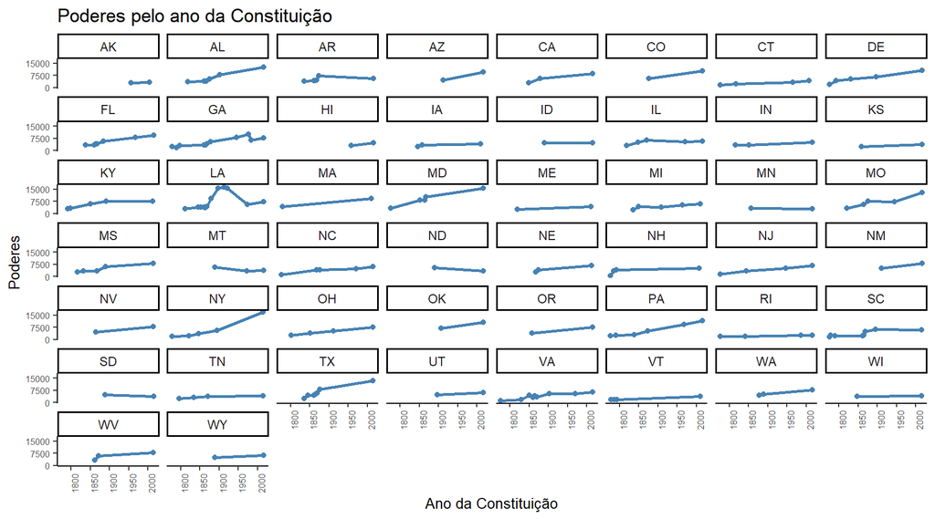

```r
constituicoes_poderes %>%
  ggplot(aes(constitution_year, poderes)) + #selecionando os eixos ano da constituicao e da variavel de interesse (poderes)
  geom_line(color = "steelblue", size = 1) + #determinando a cor e tamanho da linha
  geom_point(color = "steelblue") + #determinando a cor do ponto
  labs(title = "Poderes pelo ano da Constituição", #determinando os labels
       y = "Poderes", x="Ano da Constituição") +
  facet_wrap(~ state_abrev) + #separando por estado
  scale_y_continuous(breaks = c(0, 7500, 15000)) + #definindo as escalas do eixo y
  theme_classic() +
     theme(axis.text.x = element_text(size = 6, angle=90, hjust=1), #rotacionando o eixo x para melhorar a visualização das datas
        axis.text.y = element_text(size = 6),
        axis.title.x = element_text(size = 10),
        axis.title.y = element_text(size = 10)) #definindo o tamanho das fontes dos textos dos eixos
```

- A partir do gráfico é possível identificar uma tendência a crescimento do número de palavras que pautam regras formais para os três Poderes.